# Gozde and Liora Extension Project

Liora and Gozde

April 27, 2015

Our extension was inspired by Andreas Wimmer and Yuval Feinstein’s 2010 paper “The Rise of the Nation-State Across the World, 1816-2001.” This paper seperately tests the prevailing explanatory theories of the rise of the nation-state as the dominant form of governance. Our extension takes a similar approach, testing the major theories of support for extreme right parties in the Western European context in separate models. We operationalize the variables in these theories using the available measures from the original data set.

In order to obtain a compelling visual representation of the predictive power of different theories and models, we use the method suggested in Brian Greenhill, Michael D. Ward and Audrey Sacks (2011) “The Separation Plot: A New Visual Method for Evaluating the Fit of Models with Categorical Outcomes”, American Journal of Political Science 55 (3): 1-13. We use their R package “separationplot”.

Run necessary packages and load data (Source: Arzheimer dataverse)

```r
library(MASS)
library(nlme)
library(foreign)
library(dplyr)
```

```r
library(broom)
library(ggplot2)
library(stargazer)
library(grid)
library(gridExtra)
library(separationplot)
library(Hmisc)
data <- read.dta("nonimp.dta")

# Cleaning up data
data <- data %>%
  rename(ext_vote = rexvote,
         age_1 = age1, # (18–29 years)
         age_2 = age2, # (30–45 years)
         age_4 = age4, # (>65 years)
         edu_1 = mye1, # Education: middle/high
         edu_2 = mye2, # Education: university
         farmer_own = farmerown,
         left_right_scale = zlrs, # Left-Right Scale
         eu_neg = euschlecht, # Negative evaluation of EU membership of one's own country
         z_dem_satis = zsatisdmo, # Dissatisfied: Democracy
         dispro_elect = disp, # Disproportionality
         federalism = lfed1, # Decentralization
         z_asylumseeker = zasylumseekers ,
         z_unemp = zsur, # Unemployment rate
         z_replacement = zreplacementrate, # Unemp benefits
         max_er = rmax) # Maximum toughness in extreme right discourse
```

# Preparing data for analysis

```r
# Create centered variables for Saliance and Variance based on grand mean centering according to author

data <- data  %>%
  mutate(salience_mean_c = (salienzmean - 3.84568)) %>%
  mutate(var_c = rvar - 21.75423)

# Make male variable numeric
data <- data %>%
  mutate(male = as.numeric(male))

# Create a dummy variable for country (transform from character to factor variable)
data <- data %>%
  mutate(country = factor(sortcountry, labels = c("AT", "BE","DE-E","DE-W","DK","ES","FI","FR","GR","IT","LU","NL","NO","PT","SE")))
```

# Model 1: Adorno Thesis (Individual Characteristics and Value Orientations)

The first model is based on Theodor Adorno’s 1950 theory that support for extreme right parties (in his case, fascist parties) originates from supporters’ personality traits and value orientations, which make individuals more receptive to the appeals of extreme right parties. We operationalize “personality traits and value orientations” using the individual level characteristics from our data set: gender, age, occupation, marital status, and self-placement on a left-right scale. These variables are rather poor proxies for “personality traits and value orientations”, but provide the closest approximation from our dataset.

```r
model_1 <- glm(ext_vote ~ male + age_1 + age_2 + age_4 + edu_1 + edu_2 + farmer_own + worker + retired + unemployed + partner + left_right_scale + country - 1, data = data)
summary(model_1)
```

```
##
## Call:
## glm(formula = ext_vote ~ male + age_1 + age_2 + age_4 + edu_1 +
##     edu_2 + farmer_own + worker + retired + unemployed + partner +
##     left_right_scale + country - 1, data = data)
##
## Deviance Residuals:
##      Min        1Q    Median        3Q       Max
## -0.30021  -0.06884  -0.03093   0.00380   1.09132
##
## Coefficients:
##                    Estimate Std. Error t value Pr(>|t|)
## male              0.0175348  0.0008260  21.229  < 2e-16 ***
## age_1             0.0122444  0.0012859   9.522  < 2e-16 ***
## age_2             0.0074285  0.0011276   6.588 4.47e-11 ***
## age_4            -0.0062275  0.0015447  -4.032 5.54e-05 ***
## edu_1             0.0076812  0.0010799   7.113 1.14e-12 ***
## edu_2            -0.0034899  0.0011931  -2.925  0.00344 **
## farmer_own        0.0030320  0.0015344   1.976  0.04815 *
## worker            0.0159825  0.0012061  13.252  < 2e-16 ***
## retired           0.0064243  0.0014846   4.327 1.51e-05 ***
## unemployed        0.0227502  0.0017919  12.696  < 2e-16 ***
## partner          -0.0075340  0.0009214  -8.177 2.93e-16 ***
## left_right_scale  0.0193892  0.0001941  99.898  < 2e-16 ***
## countryAT         0.1467970  0.0029868  49.148  < 2e-16 ***
## countryBE         0.0216841  0.0023548   9.208  < 2e-16 ***
## countryDE-E      -0.0049752  0.0024590  -2.023  0.04305 *
## countryDE-W      -0.0121761  0.0019932  -6.109 1.01e-09 ***
## countryDK         0.0105116  0.0020503   5.127 2.95e-07 ***
## countryES        -0.0132509  0.0029811  -4.445 8.79e-06 ***
## countryFI        -0.0313139  0.0028591 -10.952  < 2e-16 ***
## countryFR         0.0222391  0.0021420  10.382  < 2e-16 ***
## countryGR        -0.0077147  0.0024024  -3.211  0.00132 **
## countryIT         0.0722755  0.0020539  35.190  < 2e-16 ***
## countryLU        -0.0249500  0.0045269  -5.511 3.56e-08 ***
## countryNL        -0.0180042  0.0020743  -8.680  < 2e-16 ***
## countryNO         0.0420048  0.0030777  13.648  < 2e-16 ***
## countryPT        -0.0312083  0.0031803  -9.813  < 2e-16 ***
## countrySE        -0.0255400  0.0033669  -7.586 3.32e-14 ***
## ---
## Signif. codes:  0 '***' 0.001 '**' 0.01 '*' 0.05 '.' 0.1 ' ' 1
##
## (Dispersion parameter for gaussian family taken to be 0.03583655)
##
##     Null deviance: 8785.0  on 216768  degrees of freedom
## Residual deviance: 7767.3  on 216741  degrees of freedom
##   (113626 observations deleted due to missingness)
## AIC: -106385
##
## Number of Fisher Scoring iterations: 2
```

```r
actual <- model_1$y # Create vector with actual values for vote intention for extreme right parties

log.odds <- model_1$fitted.values # Create a vector with log-odd values
# Create link function to transform log-odds into predicted probabilities
link <- function(log.odd) {
  pred.prob <- 1/(1+exp(-log.odd))
  pred.prob # returns a numeric vector of predicted probabilities
}
pred_prob <- link(log.odds) # Transform log-odds into predicted probabilities
pred_prob <- as.vector(pred_prob)
range(pred_prob) # variation in the predicted probabilities: very little variation.
```

```
## [1] 0.4713598 0.5773231
```

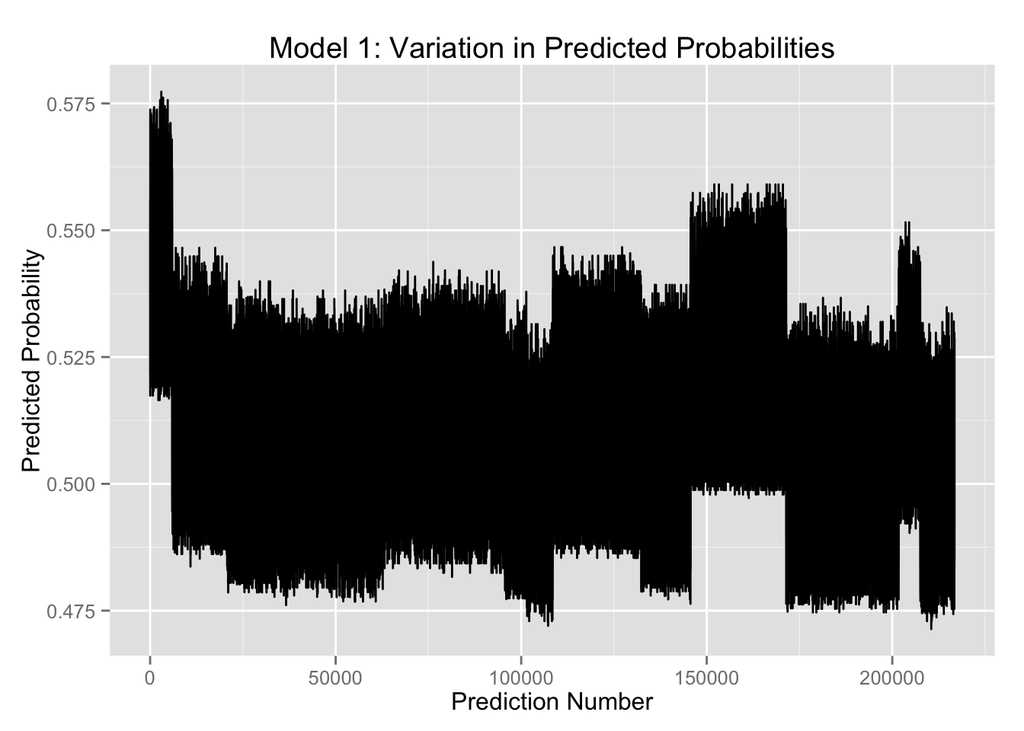

```r
# Graph variation in Predicted probabilities
pred_df <- data.frame(pred_prob)
ggplot(pred_df, aes(x = 1:length(pred_prob), y = pred_prob)) +
  geom_line() +
  xlab("Prediction Number") +
  ylab("Predicted Probability") +
  ggtitle("Model 1: Variation in Predicted Probabilities")
```

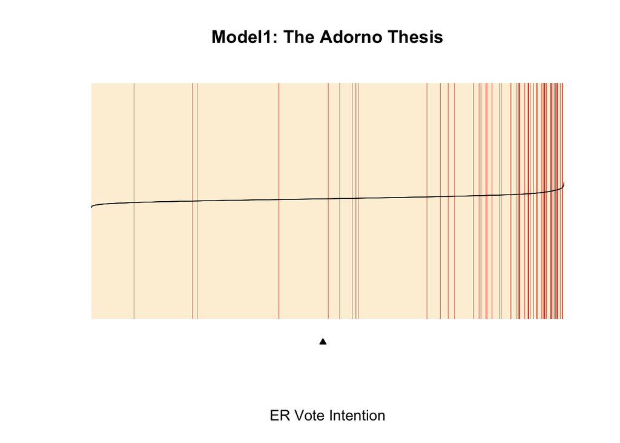

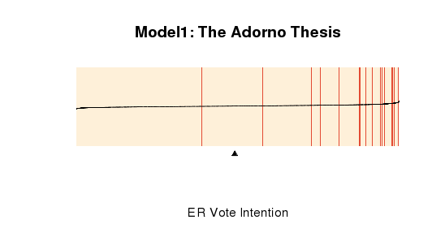

```r
# Create separation plot to visualize the predictive power of the model
separationplot(pred = pred_prob, actual = actual, type = "rect", heading = "Model1: The Adorno Thesis", xlab = "ER Vote Intention", newplot = F, line = T, lwd2 = 0.8, height = 0.5, show.expected = T)
```

# Conclusion

[output not shown]

```r
actual <- model_2$y # Create vector with actual values for vote intention for extreme right parties
log.odds <- model_2$fitted.values # Create a function with log-odds
pred_prob <- link(log.odds) # Transform log-odds into predicted probabilities
pred_prob <- as.vector(pred_prob)
range(pred_prob) # variation in the predicted probabilities: very little variation.
```

```
## [1] 0.4899779 0.5602647
```

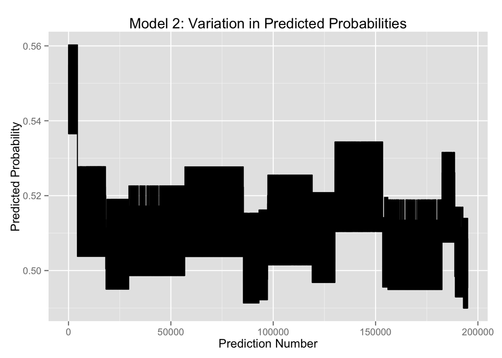

```r
# Visualize variation in predicted probabilities
pred_df <- data.frame(pred_prob)
ggplot(pred_df, aes(x = 1:length(pred_prob), y = pred_prob)) +
  geom_line() +
  xlab("Prediction Number") +
  ylab("Predicted Probability") +
  ggtitle("Model 2: Variation in Predicted Probabilities")
```

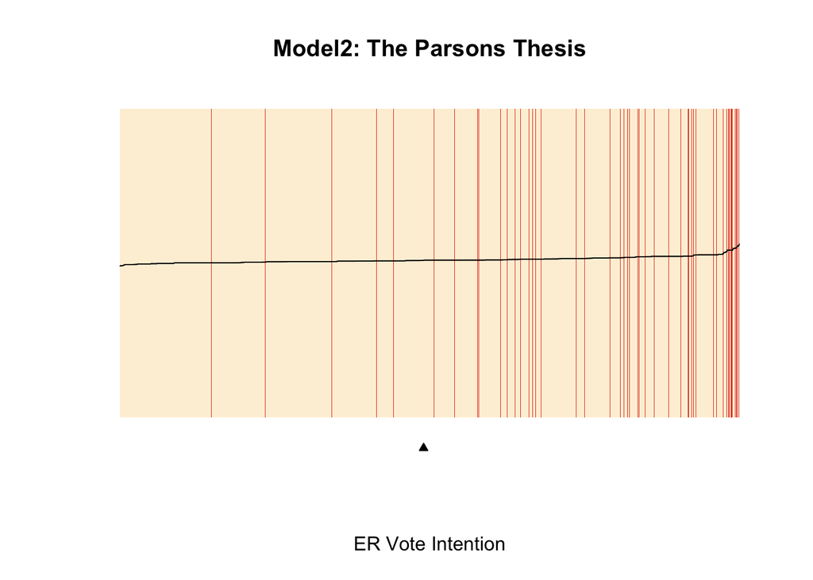

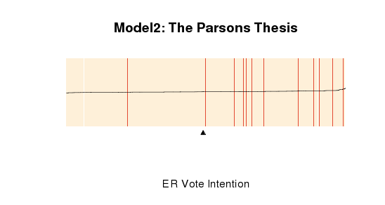

```r
# Create separation plot to visualize the predictive power of the model
separationplot(pred = pred_prob, actual = actual, type = "rect", heading = "Model2: The Parsons Thesis", xlab = "ER Vote Intention", newplot = F, line = T, lwd2 = 0.8, height = 0.5, show.expected = T)
```

# Conclusion:

Again, there is little variation in our predictive probabilities with this model. Similar to model 1, most events are aligned with higher predictive probabilities on the right hand of the graph. Yet Model 1 has slightly better predictive power as the very end of the graph is likely to be clustered with events rather than non-events as in Model 2.

# Model 3: Group Conflict Model (Various theories)

We used interactions between contextual variables in this model in line with the author’s original model.

```r
model_3 <- glm(ext_vote ~ z_asylumseeker + z_unemp + z_asylumseeker:z_unemp + z_replacement + z_replacement:z_unemp + z_replacement:z_asylumseeker + country - 1, data = data)

summary(model_3)
```

```
##
## Call:
## glm(formula = ext_vote ~ z_asylumseeker + z_unemp + z_asylumseeker:z_unemp +
##     z_replacement + z_replacement:z_unemp + z_replacement:z_asylumseeker +
##     country - 1, data = data)
##
## Deviance Residuals:
##      Min        1Q    Median        3Q       Max
## -0.21195  -0.05272  -0.03556  -0.01192   1.01223
##
## Coefficients:
##                                Estimate Std. Error t value Pr(>|t|)
## z_asylumseeker                9.269e-03  5.295e-04  17.507  < 2e-16 ***
## z_unemp                       3.227e-03  2.650e-04  12.176  < 2e-16 ***
## z_replacement                 3.004e-03  9.795e-05  30.671  < 2e-16 ***
## countryAT                     1.766e-01  2.455e-03  71.935  < 2e-16 ***
## countryBE                     2.509e-02  1.720e-03  14.590  < 2e-16 ***
## countryDE-E                   3.223e-03  2.477e-03   1.301   0.1933
## countryDE-W                   3.035e-02  1.293e-03  23.465  < 2e-16 ***
## countryDK                    -2.254e-02  2.473e-03  -9.115  < 2e-16 ***
## countryES                    -2.721e-02  3.278e-03  -8.303  < 2e-16 ***
## countryFI                    -1.298e-02  2.653e-03  -4.894 9.90e-07 ***
## countryFR                     2.490e-02  1.443e-03  17.253  < 2e-16 ***
## countryGR                     9.640e-02  2.553e-03  37.754  < 2e-16 ***
## countryIT                     1.723e-01  2.761e-03  62.403  < 2e-16 ***
## countryNL                    -5.396e-02  2.393e-03 -22.551  < 2e-16 ***
## countryNO                     4.938e-02  2.313e-03  21.343  < 2e-16 ***
## countryPT                     2.226e-02  2.692e-03   8.269  < 2e-16 ***
## countrySE                     1.093e-02  3.025e-03   3.615   0.0003 ***
## z_asylumseeker:z_unemp       -1.043e-03  1.390e-04  -7.503 6.28e-14 ***
## z_unemp:z_replacement        -2.040e-04  1.901e-05 -10.731  < 2e-16 ***
## z_asylumseeker:z_replacement -5.314e-04  4.402e-05 -12.072  < 2e-16 ***
## ---
## Signif. codes:  0 '***' 0.001 '**' 0.01 '*' 0.05 '.' 0.1 ' ' 1
##
## (Dispersion parameter for gaussian family taken to be 0.03830529)
##
##     Null deviance: 10517.0  on 252669  degrees of freedom
## Residual deviance:  9677.8  on 252649  degrees of freedom
##   (77725 observations deleted due to missingness)
## AIC: -107183
##
## Number of Fisher Scoring iterations: 2
```

```r
actual <- model_3$y # Create vector with actual values for vote intention for extreme right parties

log.odds <- model_3$fitted.values # Create a function with log-odds
pred_prob <- link(log.odds) # Transform log-odds into predicted probabilities
pred_prob <- as.vector(pred_prob)
range(pred_prob) # variation in the predicted probabilities: very little variation.
```

```
## [1] 0.4969422 0.5527891
```

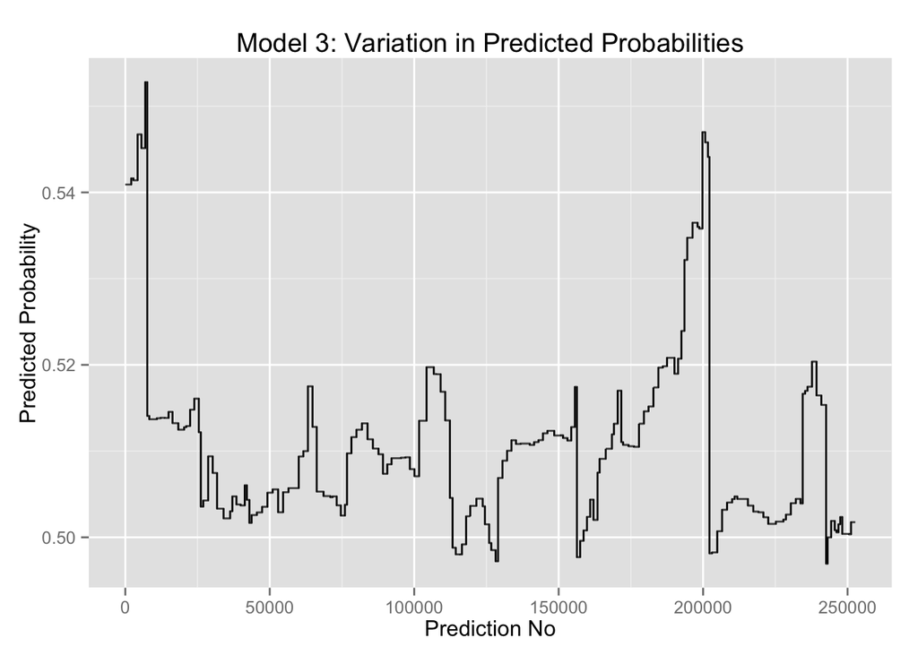

```r
# Visualize variation in predicted probabilities
pred_df <- data.frame(pred_prob)
ggplot(pred_df, aes(x = 1:length(pred_prob), y = pred_prob)) +
  geom_line() +
  xlab("Prediction No") +
  ylab("Predicted Probability") +
  ggtitle("Model 3: Variation in Predicted Probabilities")
```

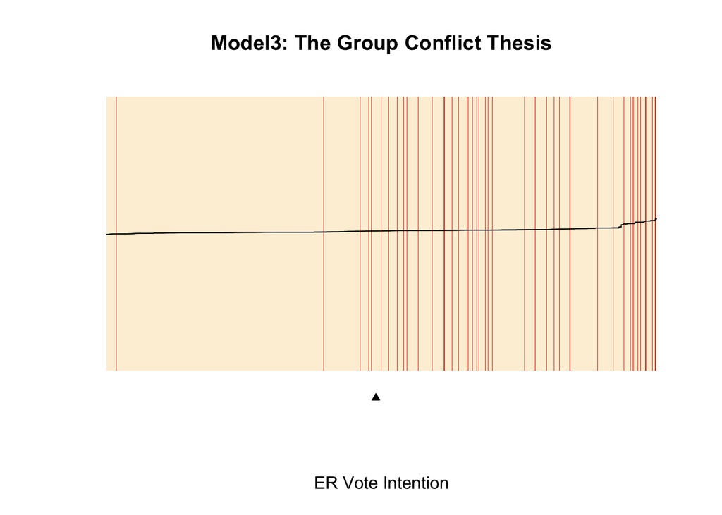

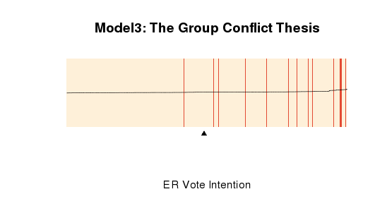

```r
# Create separation plot to visualize the predictive power of the model
separationplot(pred = pred_prob, actual = actual, type = "rect", heading = "Model3: The Group Conflict Thesis", xlab = "ER Vote Intention", newplot = F, line = T, lwd2 = 0.8, height = 0.5, show.expected = T)
```

# Conclusion:

The majority of events (the intention to vote for an extreme right party) is clustered at the right end of the model - which is in line with a good predictive model. However, in this model the distribution of events is very dispersed compared to the other two models.

# Diagnostics on our three models

The unit of analysis in each model is the individual. We wanted to apply a number of diagnostics to further test the predictive power of each model.

For model 1, we first plot fitted values vs. residuals. Since we have a categorical outcome, binned residual plots are more informative than regular plots for fitted values vs. residuals. Here we benefited greatly from this Stackexchange post: http://stats.stackexchange.com/questions/63566/unexpected-residuals-plot-of-mixed-linear-model-using-lmer-lme4-package-in-r. Then, we extract the predicted probability for an example case: a young unemployed single male who self-identifies as right-wing in Austria.

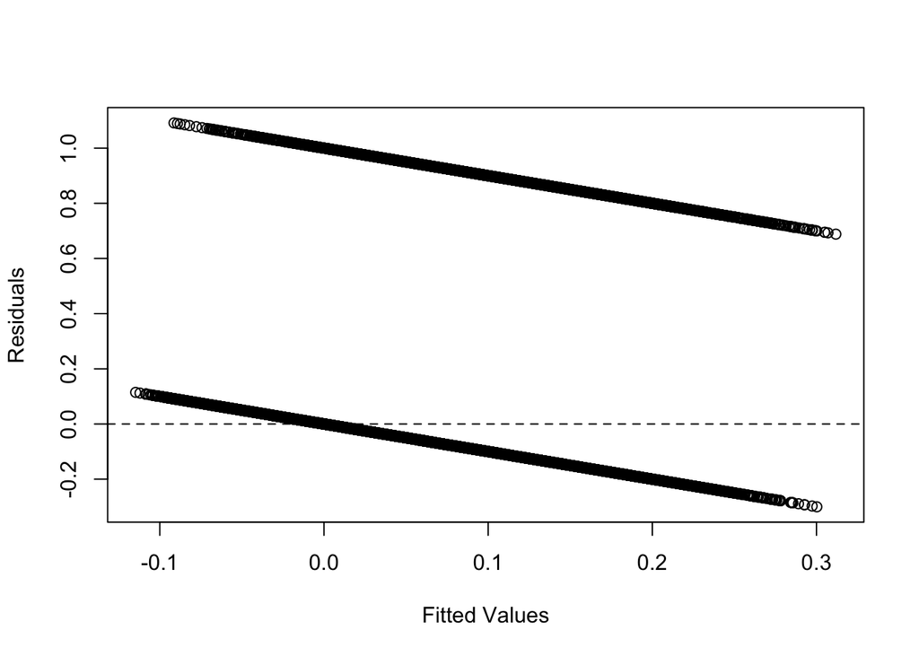

```r
plot(fitted(model_1), residuals(model_1),
  xlab = "Fitted Values", ylab = "Residuals")
  abline(h=0, lty=2) # Not very useful since the outcome is a catogorical variable and is not distributed normally.
```

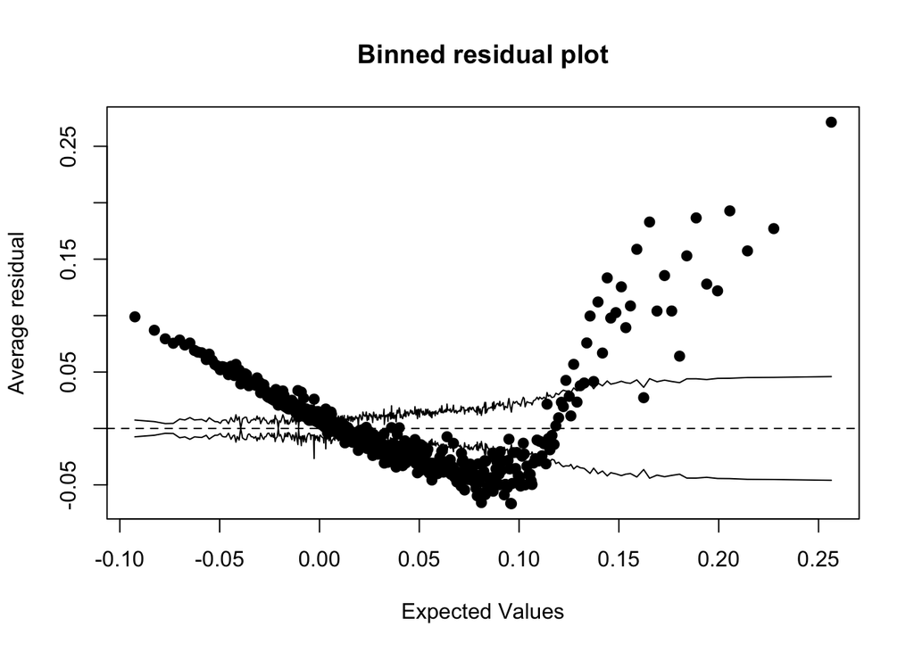

```r
library(arm) # To create binned plots for logistic models
binnedplot(predict(model_1), resid(model_1), cex.pts=1, col.int="black")
```

```r
data_model1 <- data.frame(male = 1, age_1 = 1, age_2 = 0, age_4 = 0, edu_1 = 1, edu_2 = 0, farmer_own = 0, worker = 0, retired = 0, unemployed = 1, partner = 0, left_right_scale = max(data$left_right_scale, na.rm = T), country = "AT")

predict(model_1, data_model1, type = "response")
```

```
##         1
## 0.2942591
```

For model 2, we again plot residuals vs. fitted values. This time the predictions are clustered on the left side. We then extract the predicted probability for an individual who disapproves of EU and is not satisfied with democracy.

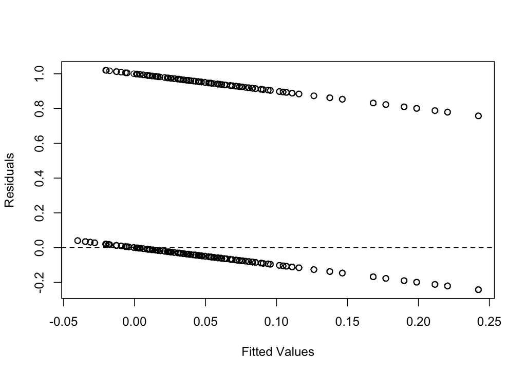

```r
plot(fitted(model_2), residuals(model_2),
  xlab = "Fitted Values", ylab = "Residuals")
  abline(h=0, lty=2)
```

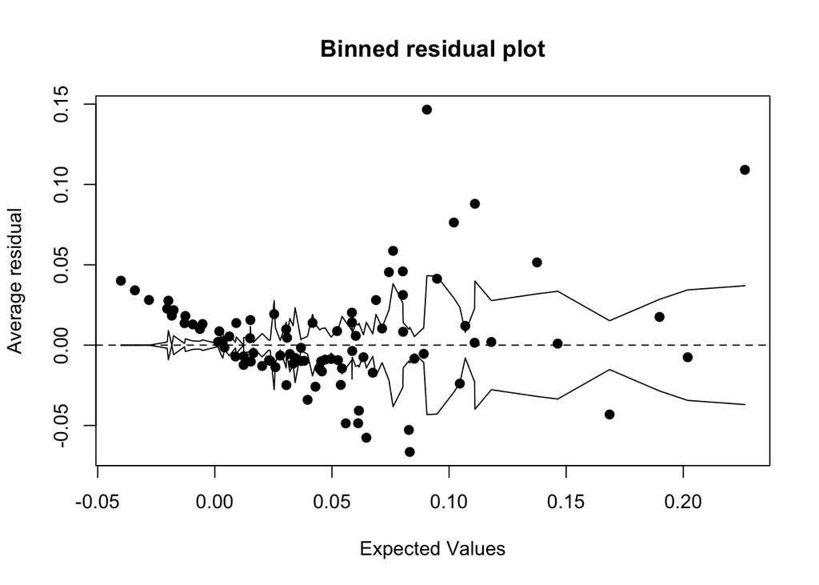

```r
binnedplot(predict(model_2), resid(model_2), cex.pts=1, col.int="black")
```

```r
data_model2 <- data.frame(eu_neg = max(data$eu_neg, na.rm = T), z_dem_satis = max(data$z_dem_satis, na.rm = T), country = "AT")

predict(model_2, data_model2, type = "response")
```

```
##         1
## 0.2422364
```

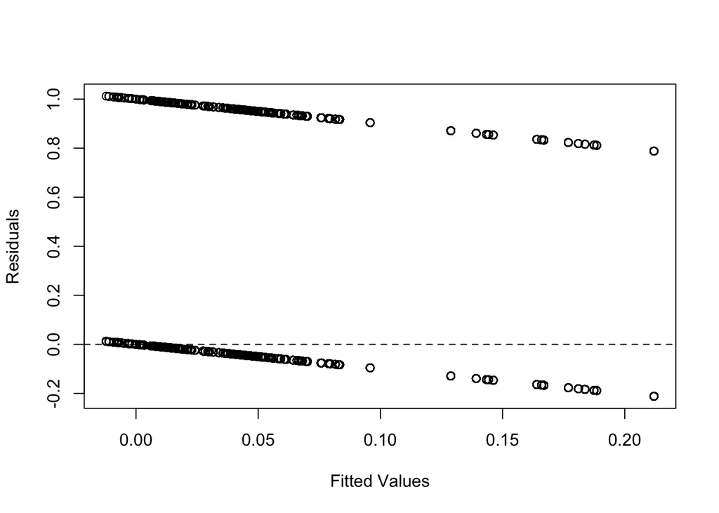

```r
plot(fitted(model_3), residuals(model_3),
  xlab = "Fitted Values", ylab = "Residuals")
  abline(h=0, lty=2)
```

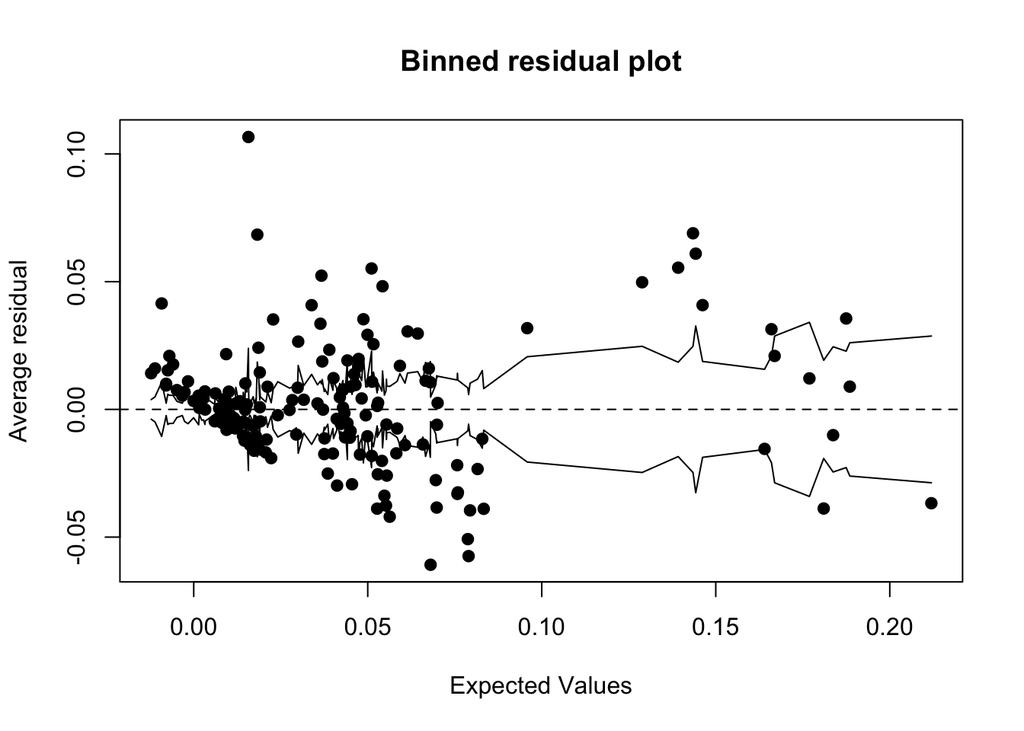

```r
binnedplot(predict(model_3), resid(model_3), cex.pts=1, col.int="black")
```

```r
#max_z_asylumseekers <- max(data$z_asylumseeker, na.rm = T) #4.45935
#max_z_unemp <- max(data$z_unemp, na.rm = T) #12.2919
#max_z_asylumseeker_z_unemp <- max(data$z_asylumseeker:data$z_unemp, na.rm = T) #-0.2445196
#max_z_replacement <- max(data$z_replacement, na.rm = T) #32.96374
#max_z_replacement_z_unemp <- max(data$z_replacement:data$z_unemp, na.rm = T) #0.5738534
#max_z_replacement_z_asylumseeker <- max(data$z_replacement:data$z_asylumseeker, na.rm = T) #0.5738534

#data_model3 <- data.frame(max_z_asylumseekers, max_z_unemp, max_z_asylumseeker_z_unemp, max_z_replacement, max_z_replacement_z_unemp, max_z_replacement_z_asylumseeker, country = "AT")
#predict(model_3, data_model3, type = "response")
#We have thus far been unable to debug the above code such that we could generate a prediction.  However, we do have a binned residual plot for this model.
```

The binned residual plots show the highest level of randomness for the second and third models, Parsons’ and the group conflict theories. This method would indicate that, contrary to our conclusions from the separation plots (see below), these models have the closest fit to the observed data. However, all of these conclusions must be qualified: the proxy variables available to us in this data set do not perfectly operationalize the theoretical models in question.

Conclusion: All Three Models

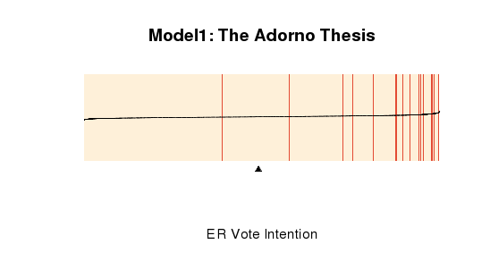

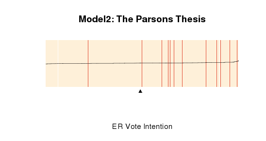

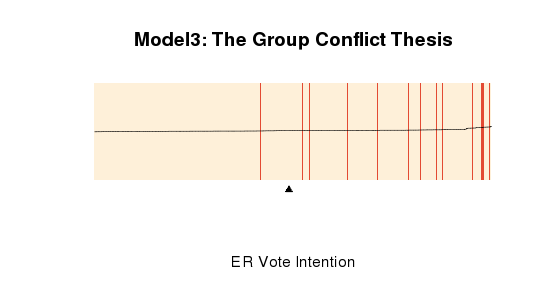

Although there is very little difference in the separation plots for all three models, our conclusion is that model 1 (the Adorno thesis which emphasizes individual-level characteristics and personal attitudes) has the most predictive power given the level of concentration of events in the upper probabilities area in the plot.

This extension breaks Arzheimer’s multi-level model into three different models that correspond to the three theoretical explanations for political orientation towards extreme right parties and movements. While we were interested in visualizing the predictive power of each theory, we acknowledge that the original model’s multi-level structure (individuals nested into election contexts in various countries) is a better way to analyze ER vote intension. That said, we think treating each country as another level that the election contexts are nested in (rather than taking countries as dummy variables) would have provided an even more compelling multi-level model.